# Quantifying Coffee Adulteration Using PLSR with Recursive Feature Elimination and Genetic Algorithm: MSC, Savitzky-Golay, and Second Derivative Preprocessing

Author

Derick Malavi

## Introduction

Coffee adulteration, such as blending premium Arabica with lower-cost Robusta, undermines quality and authenticity, posing significant challenges for consumers, producers, and regulators. High-dimensional spectroscopic data provides valuable insights for detecting such fraud, but the large number of variables necessitates effective feature selection techniques to isolate the most relevant wavelengths.

This study combines Recursive Feature Elimination (RFE) and Genetic Algorithm (GA) to identify the most critical spectral features for predicting coffee adulteration. These methods complement each other by ensuring the selection of non-redundant, high-impact features, which are crucial for optimizing model accuracy and interpretability. Spectral preprocessing techniques, including Multiplicative Scatter Correction (MSC), Savitzky-Golay smoothing, and second derivative transformation, are applied to enhance the quality of the data.

```r
# Load libraries
warning = FALSE
  suppressWarnings(suppressMessages({
  library(caret)
  library(GA)
  library(viridis)
  library(Boruta)
  library(ggplot2)
  library(dplyr)
  library(readxl)
  library(readr)
  library(pls)
  library(janitor)
  library(class)
  library(MLmetrics)
  library(MLeval)
  library(themis)
  library(ROSE)
  library(parallel)
  library(doParallel)
  library(foreach)
  library(pheatmap)
  library(mdatools)
  library(nnet)
  library(DMwR)
  library(e1071)
  library(knitr)
  library(pROC)
  library(gridExtra)
  library(FactoMineR)
  library(doSNOW)
  library(MASS)
  library(factoextra)
  library(kernlab)}))
```

## Prepare Data

```r
# Load data: msc_sg_2d spectra

hsi_msc_sg_2d <- read.csv("coffee_ground_msc_sg_2d.csv")

# Ensure we have the same number of dimensions and the range of our columns/covariates
dim(hsi_msc_sg_2d)
```

```
[1] 1469  229
```

```r
# Check a few column names
col_check <- colnames(hsi_msc_sg_2d[,c(1:6)])
col_check
```

```
[1] "sample_id"     "binary_class"  "three_class"   "adult_percent"
[5] "cal_val"       "X935.609985"
```

```r
# our response variable (adulteration percentage) is column 4
# The spectral values start from column # 6 -------> 229

# Convert the adulteration percentage to numeric for compatibility with ML
hsi_msc_sg_2d$adult_percent <- as.numeric(hsi_msc_sg_2d$adult_percent)
```

## Get the X and y variables

```r
X <- hsi_msc_sg_2d[,c(6:229)]
y <- hsi_msc_sg_2d[,4]

class(y) #Ensure y (target variable) is a numeric for regression
```

```
[1] "numeric"
```

## Visualize X

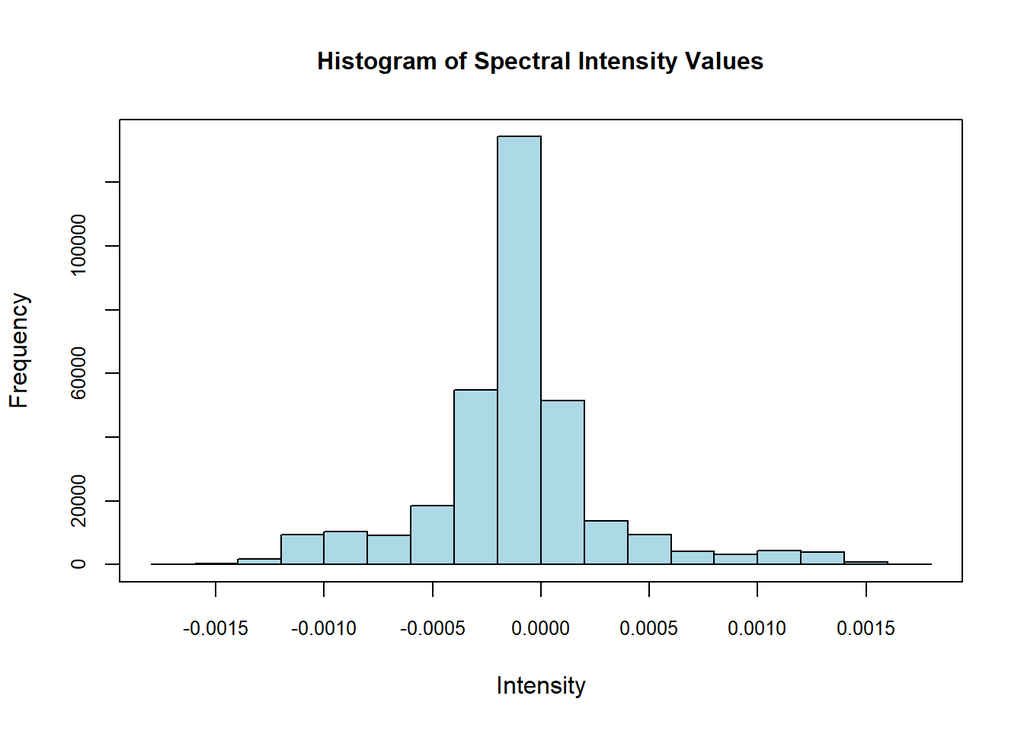

```r
hist(as.matrix(X), col = 'lightblue', cex.main = 1.0, cex.axis = 0.8,cex.lab = 1.0,
     main = 'Histogram of Spectral Intensity Values', xlab = 'Intensity'); box()
```

## Split the Data (Train_Test Split)

- We want to select features based on training data only to avoid any data leakage that could inflate model performance and make the model less generalizable to unseen data.

```r
# Subset samples for cross-validation and external validation (70/30)
# Record 1 under cal_val variable is for calibration while 2 will be for testing the model

sample<-hsi_msc_sg_2d$cal_val == 1

# Split to train and test sets
X_train <- X[sample,]
X_test <- X[!sample,]
y_train <-y[sample]
y_test <- y[!sample]

# Check length of the subsets for training and validation
dim(X_train)
```

```
[1] 1055  224
```

```r
dim(X_test)
```

```
[1] 414 224
```

```r
length(y_train)
```

```
[1] 1055
```

```r
length(y_test)
```

```
[1] 414
```

```r
# Merge the test and train data
train_data <- data.frame(X_train, y_train)
test_data <- data.frame(X_test, y_test)
```

## Define the Fitness Function for GA

- This function evaluates subsets of features selected by GA using RFE with a Random Forest (RF) model.

```r
# Fitness Function for RMSE
fitness_ga_rfe <- function(subset) {
  # Identify selected features based on the binary subset
  selected_features <- which(subset == 1)

  # Penalize empty subsets to avoid errors
  if (length(selected_features) == 0) return(Inf)

  # Subset the training feature matrix to selected features
  X_selected <- X_train[, selected_features]

  # Define control for RFE
  control <- rfeControl(functions = rfFuncs,
                        method = "cv",
                        number = 10)

  # Apply RFE to the selected subset of features
  rfe_result <- rfe(X_selected, y_train, rfeControl = control, metric = "RMSE")

  # Return the RMSE as the fitness score (lower is better)
  return(min(rfe_result$results$RMSE))
}
```

```r
# Set seed for reproducibility
set.seed(123)

num_features <- ncol(X_train) # Number of features
dataset_name <- "msc_sg_2d"   # Set the dataset name dynamically

# Define paths for the execution flag and GA result
flag_file <- paste0("ga_executed_flag_", dataset_name, ".RData")
result_file <- paste0("ga_result_", dataset_name, ".RData")

# Check if the result file exists
if (!file.exists(result_file)) {
  message("No result file found. Running the Genetic Algorithm (GA).")

  # Register cluster for caret to train the models in parallel
  cl <- makeCluster(6, type = "SOCK")
  suppressWarnings(suppressMessages(registerDoSNOW(cl)))

  # Register start time
  start_time <- Sys.time()

  # Run the Genetic Algorithm
  ga_result <- ga(
    type = "binary",
    fitness = fitness_ga_rfe,
    nBits = num_features,             # Number of features
    popSize = 20,                     # Population size
    maxiter = 50,                     # Maximum iterations
    run = 10,                         # Convergence stopping criterion
    names = colnames(train_data[, -ncol(train_data)]),  # Feature names
    pcrossover = 0.8,                 # Probability of crossover
    pmutation = 0.1,                  # Probability of mutation
    parallel = TRUE,                  # Enable parallel processing
    monitor = gaMonitor,              # Track progress
    seed = 123                        # Reproducibility
  )

  # Stop the cluster
  stopCluster(cl)

  # Register end time
  end_time <- Sys.time()
  print(paste('Time to run the GA model:', end_time - start_time))

  # Save the GA result and execution flag
  ga_executed <- TRUE
  save(ga_executed, ga_result, file = result_file)  # Save both flag and results

  message("GA execution completed and results saved.")

} else {
  # Load previously saved results
  message("Result file found. Loading saved GA results.")
  load(result_file)
  message(paste("GA already executed for dataset:", dataset_name))
}
```

```
Result file found. Loading saved GA results.
```

```
GA already executed for dataset: msc_sg_2d
```

## Visualization Plot

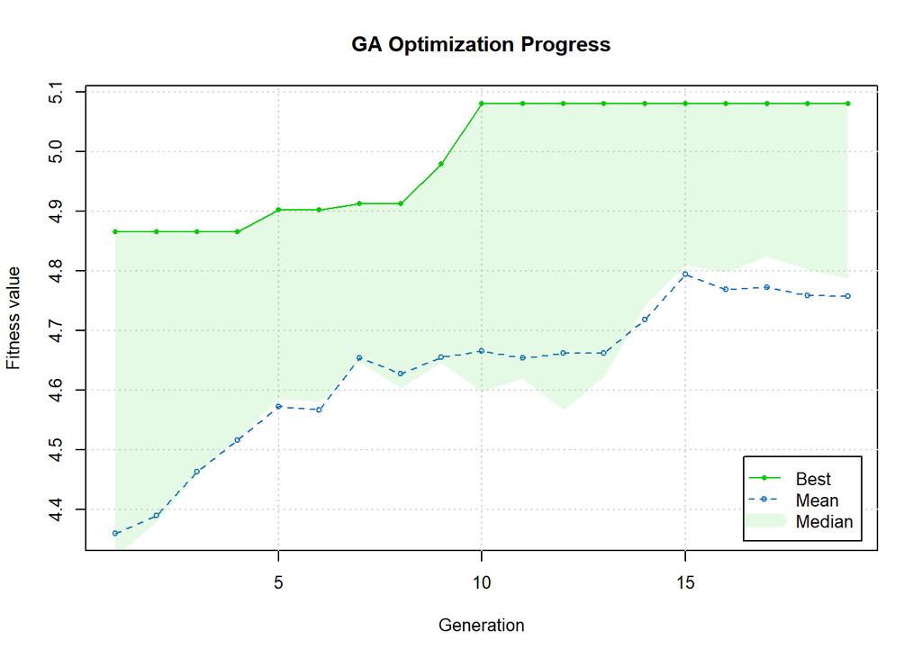

```r
par (cex = 0.8)
plot(ga_result, main = "GA Optimization Progress")
```

```r
par(cex = 1)
```

## Analyze GA results

```r
summary(ga_result)
```

```
── Genetic Algorithm ───────────────────

GA settings:
Type                  =  binary
Population size       =  20
Number of generations =  50
Elitism               =  1
Crossover probability =  0.8
Mutation probability  =  0.1

GA results:
Iterations             = 19
Fitness function value = 5.080562
Solution =
     X935.609985 X939.059998 X942.52002 X945.97998 X949.429993 X952.890015
[1,]           1           0          1          1           1           0
     X956.349976 X959.809998 X963.27002 X966.72998  ...  X1716.650024
[1,]           0           0          1          0                  1
     X1720.22998
[1,]           0
```

## Post-Selection

```r
# Get the best feature subset
best_features <- which(ga_result@solution == 1)
selected_feature_names <- colnames(train_data)[best_features]
print(selected_feature_names)
```

```
 [1] "X935.609985"  "X942.52002"   "X945.97998"   "X949.429993"  "X963.27002"
 [6] "X970.190002"  "X973.650024"  "X1011.77002"  "X1015.23999"  "X1018.710022"
[11] "X1025.650024" "X1029.119995" "X1032.589966" "X1036.060059" "X1039.530029"
[16] "X1056.900024" "X1088.199951" "X1091.680054" "X1123.040039" "X1126.52002"
[21] "X1130.01001"  "X1136.98999"  "X1150.939941" "X1154.430054" "X1164.910034"
[26] "X1168.400024" "X1171.900024" "X1175.390015" "X1178.890015" "X1185.880005"
[31] "X1189.369995" "X1192.869995" "X1206.869995" "X1210.369995" "X1213.869995"
[36] "X1217.369995" "X1220.869995" "X1224.369995" "X1234.880005" "X1238.390015"
[41] "X1241.890015" "X1245.400024" "X1252.410034" "X1262.930054" "X1266.439941"
[46] "X1283.98999"  "X1287.51001"  "X1301.560059" "X1312.109985" "X1329.699951"
[51] "X1333.219971" "X1340.26001"  "X1347.300049" "X1368.439941" "X1382.550049"
[56] "X1386.079956" "X1393.140015" "X1403.72998"  "X1421.390015" "X1431.98999"
[61] "X1442.599976" "X1449.680054" "X1453.219971" "X1456.76001"  "X1460.300049"
[66] "X1463.839966" "X1467.380005" "X1470.920044" "X1481.550049" "X1485.089966"
[71] "X1499.27002"  "X1502.819946" "X1506.369995" "X1509.910034" "X1520.560059"
[76] "X1524.109985" "X1527.660034" "X1531.209961" "X1538.319946" "X1541.869995"
[81] "X1552.530029" "X1563.199951" "X1577.430054" "X1598.790039" "X1605.920044"
[86] "X1613.040039" "X1620.170044" "X1623.73999"  "X1630.869995" "X1638.01001"
[91] "X1645.150024" "X1652.290039" "X1677.290039" "X1702.329956" "X1713.069946"
[96] "X1716.650024"
```

```r
print(paste('The number of selected variables are', length(selected_feature_names)))
```

```
[1] "The number of selected variables are 96"
```

```r
n_selected <- as.numeric(length(selected_feature_names))
```

## Create a Data frame with the Selected Features

```r
# Subset the training and test data using the selected features
X_train_selected <- X_train[, selected_feature_names]
X_test_selected <- X_test[, selected_feature_names]

# Keep y_train and y_test as-is
y_train_selected <- y_train
y_test_selected <- y_test

#Merge data_frame
train_merged <- cbind(y_train = y_train_selected, X_train_selected)
test_merged <- cbind(y_test = y_test_selected, X_test_selected)

dim(train_merged)
```

```
[1] 1055   97
```

```r
dim(test_merged)
```

```
[1] 414  97
```

## Check correlations by HeatMaps

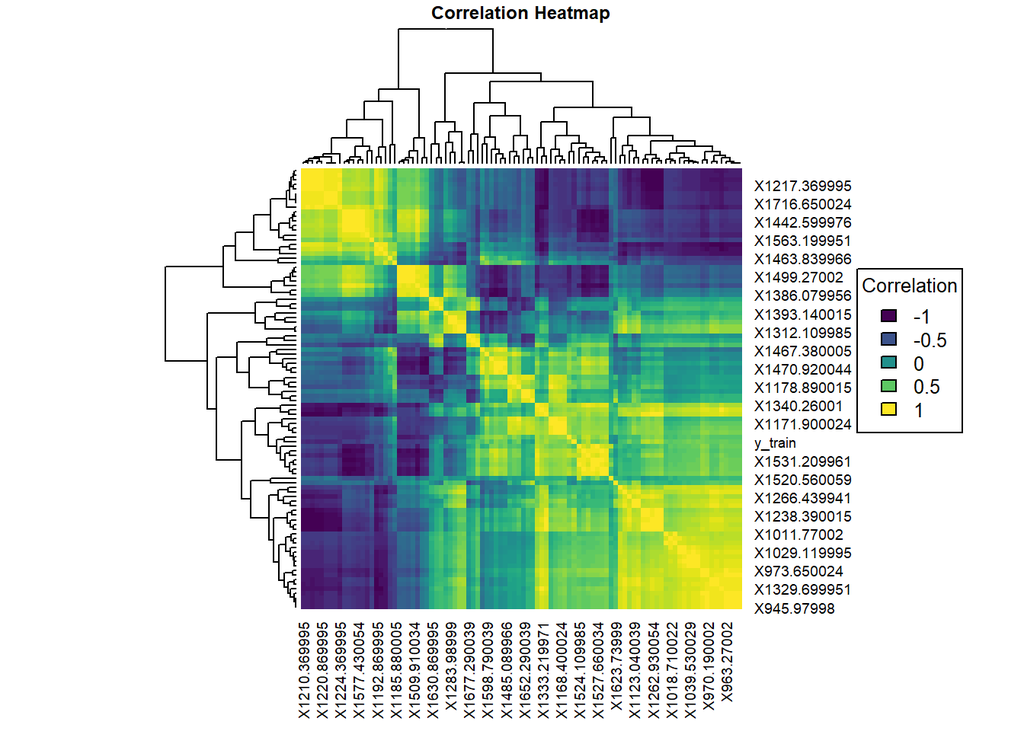

```r
n_features <- length(n_selected)

#Calculate correlations
corr <- cor(train_merged[, -(n_features+1)])

# Create a heat map
par(cex.main = 0.6)
heatmap(corr, symm = TRUE,
        col = viridis(50),
        main = "Correlation Heatmap")

# Add legend

legend("right",
       legend = seq(-1, 1, by = 0.5),  # Correlation range
       fill = viridis(5),
       title = "Correlation", cex = 0.8)
```

## Train Models

- We will train models based on the reduced number of features.

```r
# Set random seed for reproducibility
set.seed (123)

# Set up the training control(10 folds 10 times cross_validation)
control <- trainControl(method = "repeatedcv", number = 10, repeats = 10,
                        savePredictions = "final",
                        summaryFunction = defaultSummary,
                        selectionFunction = 'best', allowParallel = TRUE)

# We used oneSE for classification. For regression, we will use 'best': a model that minimizes RMSECV
```

```r
#Set the metric as accuracy
metric<-"RMSE"
```

```r
# Hyperparameter Tuning
# We will use tuneLength to automatically determine the optimal number of PLS components
```

```r
set.seed(123)
#Register cluster for caret to train the models in parallel
cl<-makeCluster(6,type = "SOCK")
suppressWarnings(suppressMessages(
  registerDoSNOW(cl)))

# Start_time
start_time<-Sys.time()

#Train the model using cross-validation (10 folds, 10 times)
fit_pls_msc_sg_2d<-train(y = train_merged[,1],
                         x = train_merged[,-1],
                         method = 'pls', tuneLength = 60,
                         trControl = control,
                         metric = metric)
#End_time
end_time<-Sys.time()

model_training_time<-end_time-start_time

stopCluster(cl) # Stop the parallel run cluster

print(model_training_time)
```

```
Time difference of 8.96094 secs
```

```r
# Display regression results
print(fit_pls_msc_sg_2d)
```

```
Partial Least Squares

1055 samples
  96 predictor

No pre-processing
Resampling: Cross-Validated (10 fold, repeated 10 times)
Summary of sample sizes: 949, 949, 949, 948, 949, 950, ...
Resampling results across tuning parameters:

  ncomp  RMSE       Rsquared   MAE
   1     19.694448  0.5334604  15.766095
   2     17.589261  0.6276748  13.745334
   3     13.276950  0.7892345  10.517165
   4     12.514088  0.8129996   9.994970
```

[output cut: 59 more lines]

## Save the models for future use

```r
saveRDS(fit_pls_msc_sg_2d, "fit_pls_msc_sg_2d.rds")
```

## Plot the cross-validation results —–> Model Selection

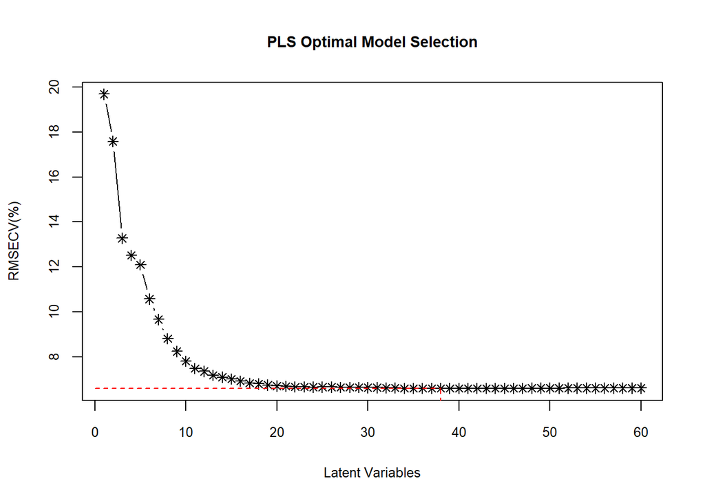

```r
# Imbalanced Data
pls_data <- fit_pls_msc_sg_2d$results
best_Lvs = fit_pls_msc_sg_2d$bestTune$ncomp
y_RMSE = pls_data$RMSE[pls_data$ncomp == best_Lvs]
plot(pls_data$ncomp,pls_data$RMSE, type = "b",col = "black",pch = 8,cex.axis = 0.8,
     xlab = "Latent Variables", ylab = "RMSECV(%)",cex.lab = 0.9,
     main = 'PLS Optimal Model Selection',
     cex.main = 0.9,
     cex.lab = 0.8)
# Add line from x-axis to the specific point
segments(x0 = best_Lvs, y0 = 0, x1 = best_Lvs, y1 = y_RMSE, col = "red", lty = 2)

# Add line from y-axis to the specific point
segments(x0 = 0, y0 = y_RMSE, x1 = best_Lvs, y1 = y_RMSE, col = "red", lty = 2)
```

## Display the cross-validation results

```r
print(paste('The optimal parameters for training the pls model is',
            fit_pls_msc_sg_2d$bestTune$ncomp, 'components'))
```

```
[1] "The optimal parameters for training the pls model is 38 components"
```

## Display CV Results in Tables

```r
kable(fit_pls_msc_sg_2d$results)
```

| ncomp | RMSE | Rsquared | MAE | RMSESD | RsquaredSD | MAESD |
| --- | --- | --- | --- | --- | --- | --- |
| 1 | 19.694448 | 0.5334604 | 15.766095 | 1.1460625 | 0.0505377 | 0.9164915 |
| 2 | 17.589261 | 0.6276748 | 13.745334 | 1.5399549 | 0.0591559 | 0.8243205 |
| 3 | 13.276950 | 0.7892345 | 10.517165 | 1.0916960 | 0.0318764 | 0.8048343 |
| 4 | 12.514088 | 0.8129996 | 9.994970 | 0.8669930 | 0.0240106 | 0.7243584 |
| 5 | 12.098475 | 0.8250459 | 9.627481 | 0.9585983 | 0.0253432 | 0.6986998 |
| 6 | 10.569494 | 0.8665769 | 8.482546 | 0.7387887 | 0.0178106 | 0.6302764 |
| 7 | 9.662173 | 0.8886279 | 7.773494 | 0.6086376 | 0.0130447 | 0.5217192 |
| 8 | 8.802257 | 0.9076320 | 7.009879 | 0.5508671 | 0.0110508 | 0.4831578 |
| 9 | 8.237501 | 0.9191597 | 6.666762 | 0.5110345 | 0.0095373 | 0.4559939 |
| 10 | 7.798368 | 0.9276352 | 6.301106 | 0.5141126 | 0.0092560 | 0.4666924 |
| 11 | 7.470929 | 0.9334899 | 6.018139 | 0.4727382 | 0.0080961 | 0.4296262 |
| 12 | 7.350500 | 0.9356831 | 5.885408 | 0.4533341 | 0.0074594 | 0.3983933 |
| 13 | 7.171436 | 0.9388147 | 5.637108 | 0.5004015 | 0.0079782 | 0.4031330 |
| 14 | 7.088785 | 0.9402120 | 5.628093 | 0.4881546 | 0.0079227 | 0.4055174 |
| 15 | 7.003732 | 0.9416264 | 5.553940 | 0.4886446 | 0.0077555 | 0.3961924 |
| 16 | 6.917502 | 0.9430883 | 5.489033 | 0.4546233 | 0.0072944 | 0.3851330 |
| 17 | 6.827595 | 0.9445064 | 5.407251 | 0.4282757 | 0.0069606 | 0.3720493 |
| 18 | 6.789162 | 0.9451951 | 5.374079 | 0.4013385 | 0.0065059 | 0.3537087 |
| 19 | 6.737343 | 0.9460537 | 5.334803 | 0.3856626 | 0.0062502 | 0.3366905 |
| 20 | 6.696487 | 0.9466856 | 5.316056 | 0.3911392 | 0.0062932 | 0.3337391 |
| 21 | 6.676159 | 0.9469755 | 5.293588 | 0.3852983 | 0.0062442 | 0.3287395 |
| 22 | 6.662248 | 0.9472092 | 5.276190 | 0.3941567 | 0.0063854 | 0.3248922 |
| 23 | 6.656217 | 0.9472985 | 5.261711 | 0.4072656 | 0.0065907 | 0.3382767 |
| 24 | 6.646222 | 0.9474440 | 5.247423 | 0.4106540 | 0.0066470 | 0.3460752 |
| 25 | 6.648450 | 0.9474482 | 5.247193 | 0.4157232 | 0.0067264 | 0.3468642 |
| 26 | 6.648206 | 0.9474630 | 5.224336 | 0.4344440 | 0.0069540 | 0.3554475 |
| 27 | 6.642360 | 0.9475637 | 5.218872 | 0.4345683 | 0.0069908 | 0.3551515 |
| 28 | 6.640020 | 0.9476024 | 5.213814 | 0.4351769 | 0.0069585 | 0.3491717 |
| 29 | 6.634858 | 0.9477104 | 5.216067 | 0.4398771 | 0.0070332 | 0.3533949 |
| 30 | 6.626760 | 0.9478656 | 5.204375 | 0.4364644 | 0.0069211 | 0.3473936 |
| 31 | 6.626149 | 0.9478777 | 5.188410 | 0.4495408 | 0.0070960 | 0.3529170 |
| 32 | 6.617279 | 0.9479967 | 5.172801 | 0.4424923 | 0.0070391 | 0.3519427 |
| 33 | 6.607536 | 0.9481608 | 5.170134 | 0.4408443 | 0.0069858 | 0.3486618 |
| 34 | 6.596312 | 0.9483439 | 5.157057 | 0.4396766 | 0.0069737 | 0.3486775 |
| 35 | 6.590245 | 0.9484307 | 5.155868 | 0.4336885 | 0.0069156 | 0.3397532 |
| 36 | 6.588027 | 0.9484664 | 5.152404 | 0.4354636 | 0.0069511 | 0.3380776 |
| 37 | 6.585449 | 0.9485079 | 5.151900 | 0.4367975 | 0.0069752 | 0.3409405 |
| 38 | 6.585318 | 0.9485122 | 5.151737 | 0.4375476 | 0.0069983 | 0.3411535 |
| 39 | 6.587802 | 0.9484771 | 5.153129 | 0.4378319 | 0.0069757 | 0.3417009 |
| 40 | 6.588508 | 0.9484665 | 5.156129 | 0.4406629 | 0.0070249 | 0.3430961 |
| 41 | 6.590514 | 0.9484378 | 5.155539 | 0.4398526 | 0.0070137 | 0.3420548 |
| 42 | 6.592752 | 0.9484013 | 5.157041 | 0.4411633 | 0.0070352 | 0.3428623 |
| 43 | 6.593243 | 0.9483950 | 5.157301 | 0.4411090 | 0.0070381 | 0.3427925 |
| 44 | 6.593205 | 0.9483968 | 5.159027 | 0.4404690 | 0.0070338 | 0.3425168 |
| 45 | 6.593799 | 0.9483866 | 5.158055 | 0.4409310 | 0.0070400 | 0.3429727 |
| 46 | 6.595709 | 0.9483591 | 5.158565 | 0.4403961 | 0.0070359 | 0.3425913 |
| 47 | 6.596460 | 0.9483446 | 5.158022 | 0.4401380 | 0.0070386 | 0.3424178 |
| 48 | 6.597700 | 0.9483259 | 5.159995 | 0.4398257 | 0.0070369 | 0.3423811 |
| 49 | 6.598795 | 0.9483094 | 5.162009 | 0.4392995 | 0.0070249 | 0.3421236 |
| 50 | 6.600067 | 0.9482899 | 5.163692 | 0.4390872 | 0.0070201 | 0.3421307 |
| 51 | 6.600882 | 0.9482758 | 5.164193 | 0.4398289 | 0.0070338 | 0.3427978 |
| 52 | 6.602412 | 0.9482526 | 5.165172 | 0.4394462 | 0.0070314 | 0.3423528 |
| 53 | 6.603121 | 0.9482418 | 5.166352 | 0.4394225 | 0.0070276 | 0.3427015 |
| 54 | 6.603209 | 0.9482414 | 5.166509 | 0.4392655 | 0.0070229 | 0.3427942 |
| 55 | 6.603175 | 0.9482424 | 5.166339 | 0.4390563 | 0.0070188 | 0.3427073 |
| 56 | 6.603108 | 0.9482439 | 5.166211 | 0.4390303 | 0.0070183 | 0.3427763 |
| 57 | 6.603133 | 0.9482433 | 5.166234 | 0.4391208 | 0.0070200 | 0.3428950 |
| 58 | 6.603194 | 0.9482423 | 5.166365 | 0.4390512 | 0.0070196 | 0.3427687 |
| 59 | 6.603278 | 0.9482412 | 5.166443 | 0.4390717 | 0.0070197 | 0.3427548 |
| 60 | 6.603333 | 0.9482402 | 5.166515 | 0.4391953 | 0.0070218 | 0.3428842 |

```r
# Select row for the optimal model
opt_row <- fit_pls_msc_sg_2d$results %>%
  filter(ncomp==fit_pls_msc_sg_2d$bestTune$ncomp)

kable(opt_row)
```

| ncomp | RMSE | Rsquared | MAE | RMSESD | RsquaredSD | MAESD |
| --- | --- | --- | --- | --- | --- | --- |
| 38 | 6.585318 | 0.9485122 | 5.151737 | 0.4375476 | 0.0069983 | 0.3411535 |

## Test the model performance on test data

```r
#Predict on the test set
observed <- test_merged$y_test

predictions <- predict(fit_pls_msc_sg_2d,newdata=test_merged)

# Generate predictions
results <- postResample(predictions, observed)

print(results)
```

```
     RMSE  Rsquared       MAE
8.1601672 0.9282705 6.5949738
```

```r
RMSEP = results[[1]]
R2 = results[[2]]
MAE = results[[3]]

cat('The RMSEP for the model on external validation is:', RMSEP,'\n')
```

```
The RMSEP for the model on external validation is: 8.160167
```

```r
cat('The R Squared value for the model is:', R2)
```

```
The R Squared value for the model is: 0.9282705
```

```r
# Calculate Residual Predictive Deviation to check model performance

RPD = sd(observed)/RMSEP

print(paste('The RPD values for the model is', round(RPD,2)))
```

```
[1] "The RPD values for the model is 3.57"
```

## Visualizations

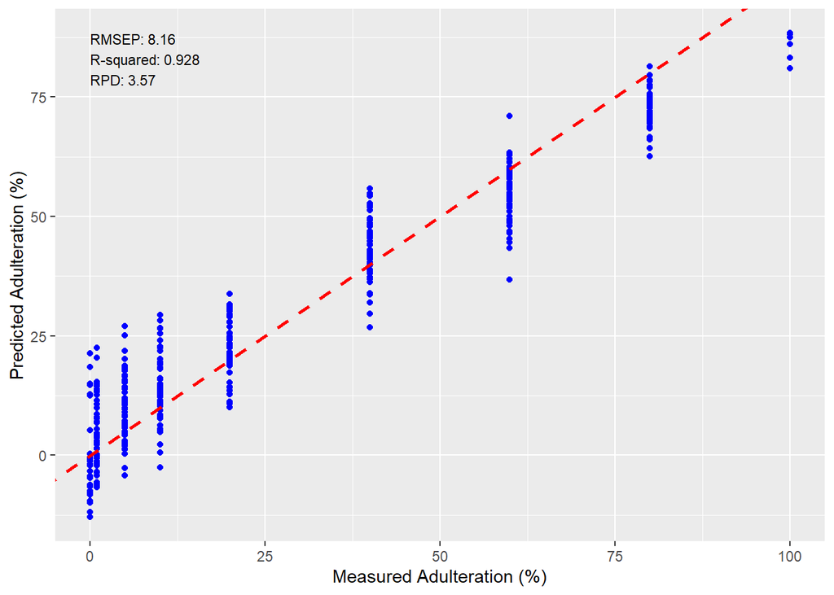

```r
# predicted vs observed line and scatter
# Create a data frame
results_df <- data.frame(observed=observed, predictions=predictions)

results_df %>%
  ggplot(aes(x = observed, y = predictions)) +
  geom_point(color = "blue") +
  geom_abline(slope = 1, intercept = 0, color = "red",
              linetype = "dashed", linewidth = 1) +
  labs( x = "Measured Adulteration (%)",
    y = "Predicted Adulteration (%)") +
  annotate("text",
    x = min(observed), y = max(predictions),
    label = paste("RMSEP:", round(RMSEP, 2),
      "\nR-squared:", round(R2, 3),
      "\nRPD:", round(RPD, 2)),
    hjust = 0, vjust = 1, size = 3, color = "black") +
  theme(
    axis.title = element_text(color = "black", size = 10),
    axis.text = element_text(color = "black"))+
  theme_gray()
```

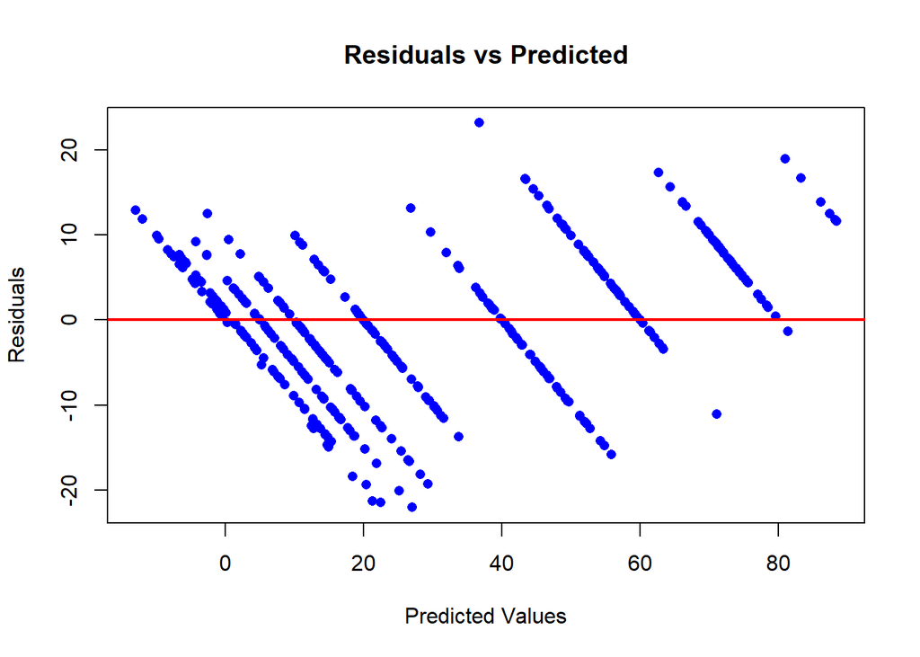

```r
# Check residuals

residuals <- observed - predictions

# Plot Residuals
plot(predictions, residuals,
     xlab = "Predicted Values",
     ylab = "Residuals",
     main = "Residuals vs Predicted",
     pch = 16, col = "blue")
abline(h = 0, col = "red", lwd = 2)
```

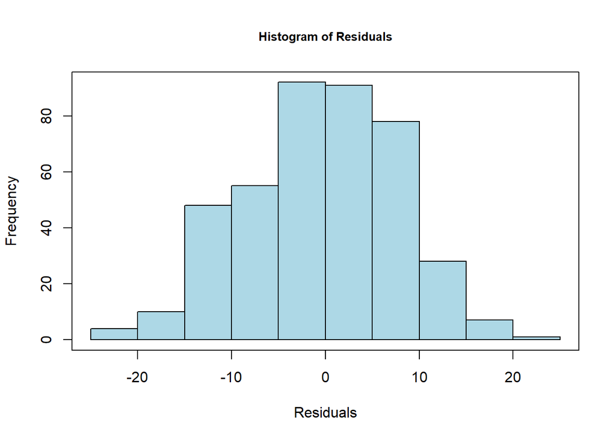

```r
hist(residuals,
     main = "Histogram of Residuals",
     xlab = "Residuals", cex.main = 0.8,
     col = "lightblue", border = "black"); box()
```

## Conclusion

- Genetic Algorithm and PLS demonstrates excellent performance in predicting adulteration in ground coffee. The model achieves an RPD value of 3.6.